# Tidy Tuesday 6/20/23

Mark Wooten

2023-06-23

```r
library(tidytuesdayR)
library(tidyverse)
library(usmap)
```

Let’s get started on a new Tidy Tuesday project. First thing’s first: let’s get some data.

```r
tuesdata <- tidytuesdayR::tt_load('2023-06-20')
ufo_sightings <- tuesdata$`ufo_sightings`
places <- tuesdata$`places`
day_parts_map <- tuesdata$`day_parts_map`
```

We’re looking at UFO sightings and the first thing I’d like to know is what state had the most UFO sightings in 2022. So let’s get to work making a map with that data. To start out, I’ll make sure I’ve got just the date portion of the date/time as a seperate column. Then I can subset the data into only sightings from 2022. From there I’ll generate a simple count of observations grouped by US state.

```r
ufo_sightings$sight_year <- as.Date(ufo_sightings$reported_date_time_utc)

ufo_22 <- ufo_sightings %>%
  filter(between(sight_year, as.Date("2022-01-01"), as.Date("2022-12-31")),
         country_code == 'US') %>%
  count(state)
```

Now that we’ve got our data subset, let’s plot it. This is my first time plotting a map!

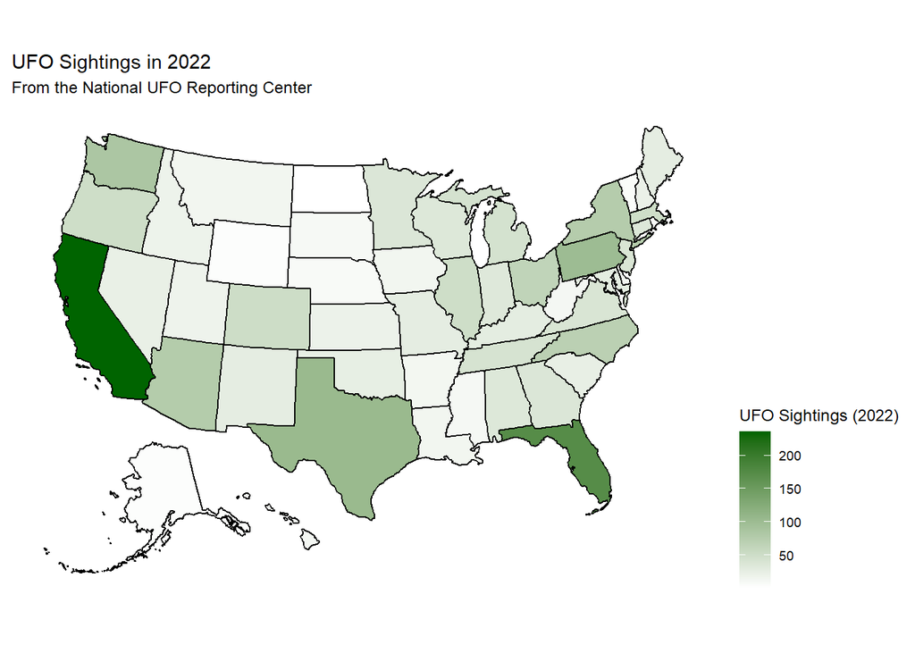

```r
plot_usmap(data = ufo_22, values = "n", color = "black") +
  scale_fill_continuous(
    low = "white", high = "darkgreen", name = "UFO Sightings (2022)",
    label = scales::comma) +
  theme(legend.position = "right") +
  labs(title = "UFO Sightings in 2022",
       subtitle = "From the National UFO Reporting Center")
```

Unsurprisingly, states with larger populations seem to have more UFO sightings. Makes sense. What if we could look at it on a per 10,000 person basis? For that, we’ll have to get our data shaped up a little differently. First, I’m going to take the ‘places’ data and get a sum of the populations of each state. Then, I can join that data to the sighting data for 2022 while creating a variable for the sightings per 10,000 people (‘sight_10k’)

```r
pop_combined <- places %>%
  select(state, country_code, population) %>%
  filter(country_code == 'US') %>%
  group_by(state) %>%
  summarise(tot_pop = sum(population))

sight_percap <- left_join(ufo_22, pop_combined, by = 'state') %>%
  mutate(pop_10k = tot_pop/10000,
         sight_10k = n/pop_10k)
```

Now that we’ve got a rate of sightings per 10,000 people let’s run that map again.

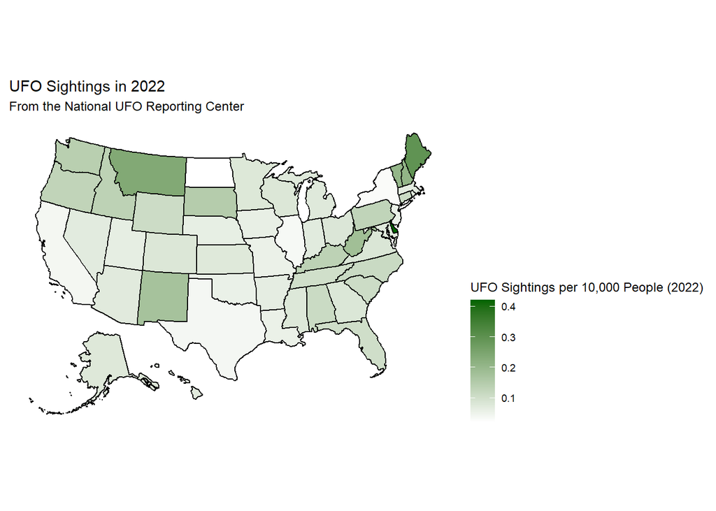

```r
plot_usmap(data = sight_percap, values = "sight_10k", color = "black") +
  scale_fill_continuous(
    low = "white", high = "darkgreen", name = "UFO Sightings per 10,000 People (2022)",
    label = scales::comma) +
  theme(legend.position = "right") +
  labs(title = "UFO Sightings in 2022",
       subtitle = "From the National UFO Reporting Center")
```

That changes the map! A lot of smaller population states are reporting UFO sightings at higher rates. Rurality seems to play into the numbers more than population.

The next thing I’m curious about is the time of day that sightings occur. Let’s drill down into that, shall we?